# rs-ws-06-2

CoWeber, aschupp, santowsa

18 Januar 2018

# Accurary assessment land-cover classification

The execution of accurary assessment for first land-cover classification is divided into three parts:

1. Preparation and create test and train samples outward the land-covers (Shapefile) in R
2. Implementation of land-cover classification with train data and matrix output (QGIS / OTB)
3. Calculation of Cohen’s Kappa for each run (R)

### 1. Preparation and sample creation

```r
setwd("D:/mpg/daten/ln")
library(caret)
library(rgdal)
library(raster)
path <- "D:/mpg/daten/ln"
path$samples <- "samples/"

### Create random samples with data splitting function from caret-package

train <- readOGR("merge_cal_shp.shp") #load training sites
sep_train <- lapply(seq(length(train)), function(i) train[i,])
#data splitting
train_sample <- createDataPartition(train@data$LN_new, p = 0.80, list = F, times = 6)

#create train and test data
samples <- lapply(seq(ncol(train_sample)), function(x){

  trainx <- lapply(train_sample[,x], function(i) rbind(sep_train[[i]]))
  trainx <- do.call("rbind", trainx)

  test <- lapply(seq(length(train))[-train_sample[,x]], function(j) rbind(sep_train[[j]]))
  test <- do.call("rbind", test)

  return(list(train = trainx, test = test))

})

#output new shp's in new output folder:

dir.create(paste0(path$samples))

for (a in seq(6)){
  writeOGR(samples[[a]]$train, dsn = paste0(path$sample, "train_", as.character(a), ".shp"), driver = "ESRI Shapefile", layer = "train")
  writeOGR(samples[[a]]$test, dsn = paste0(path$sample, "test_", as.character(a), ".shp"), driver = "ESRI Shapefile", layer = "test")
}
```

Through step one we’ve got 6x train and test shapefile for the land-cover classificiation with OTB and the verification in step three.

### 2. Implementation in QGIS / OTB

- “OTB TrainImageClassifier (rf)” and “OTB Image Classifier” in use.
- the matrices for step three are taken from the step otb trainimageclassifier (rf)

–> If we look at the classifications outward only 80% of the initially train areas dataset compared to the 100% train area dataset it seems that the result of classification gets better with the smaller dataset. An Example for one classification based on one 80% train data below:

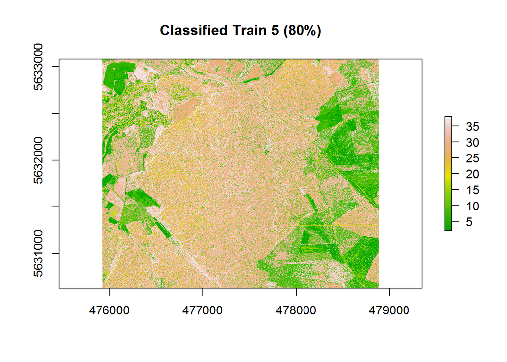

### 3. Kappa

The comKappa function is taken from TNauss since package ctab wasn’t as easy as excpected to understand and use surely in the script. The function can be seen below:

```r
compKappa <- function(ctable){
  ctable <- ctable/sum(ctable)
  categories <- nrow(ctable)

  # Fraction of agreement
  pagrm <- 0
  for(i in seq(categories)){
    pagrm <- pagrm + ctable[i,i]
  }

  # Expected fraction of agreement subject to the observed distribution
  pexpct <- 0
  for(i in seq(categories)){
    pexpct <- pexpct + sum(ctable[i,]) * sum(ctable[,i])
  }

  # Kappa index
  kappa <- (pagrm - pexpct)/(1 - pexpct)

  return(kappa)
}
```

Finally the calculation of Cohen’s Kappa for each 80%-train dataset and the matrix data as basis: *** train_3 created like the other 5 test and train datasets returned an error in OTB and could not be used for Kappa calculation.

```r
setwd("D:/mpg/skript/remote_sensing/rs_09_aktuell/models/") #create WD
x_files=list.files(pattern=".xml$", full.names=T)# create list with matrixfiles
source("D:/mpg/skript/remote_sensing/rs-ws-06-2/kappa_func.R")

#KAPPA function is the comKappa function written with a for loop and prints the results as part #of the function.
#The results are saved in a list.

KAPPA=function(listfile){
  d=data.frame()
  for (i in listfile){
    a=read.table(i,sep = ",")
    c=compKappa(a)
    c=round(c,digits=4)
    print(paste0("the kappa value for ", substring(i,3,13), " is: ", c))
    d=rbind(d,c)
  }
  return(d)
}

##################################################

df=KAPPA(listfile = x_files)
```

```
## [1] "the kappa value for matrix_t_1. is: 0.2967"
## [1] "the kappa value for matrix_t_2. is: 0.3404"
## [1] "the kappa value for matrix_t_4. is: 0.3541"
## [1] "the kappa value for matrix_t_5. is: 0.3682"
## [1] "the kappa value for matrix_t_6. is: 0.3546"
## [1] "the kappa value for matrix_t_al is: 0.2407"
```

The Kappa values show’s only a sufficient accordance with values between 0.20-0.40. The Kappa value on the basis of 100% train area data shows the lowest values with 0.2407. A reduction of or selection of the train areas can improve the results a little.